# Risk Factor Analysis

## Outcome Variable

**Outcome Variable:** haz

## Predictor Variables

**Intervention Variable:** perdiar6

**Adjustment Set:**

- arm
- sex
- W_mage
- meducyrs
- feducyrs
- hhwealth_quart
- hfoodsec
- W_mhtcm
- W_mwtkg
- W_mbmi
- W_birthwt
- W_birthlen
- W_nrooms
- month
- brthmon
- impfloor
- impsan
- safeh20
- delta_W_mage
- delta_meducyrs
- delta_feducyrs
- delta_hhwealth_quart
- delta_hfoodsec
- delta_W_mhtcm
- delta_W_mwtkg
- delta_W_mbmi
- delta_W_birthwt
- delta_W_birthlen
- delta_W_nrooms
- delta_month
- delta_brthmon
- delta_impfloor
- delta_impsan
- delta_safeh20

## Stratifying Variables

The analysis was stratified on these variable(s):

- agecat

## Data Summary

| agecat | perdiar6 | n_cell | n | outcome_variable |
| --- | --- | --- | --- | --- |
| Birth | 0% | 1281 | 2985 | haz |
| Birth | (0%, 5%] | 839 | 2985 | haz |
| Birth | >5% | 865 | 2985 | haz |
| 6 months | 0% | 1916 | 4383 | haz |
| 6 months | (0%, 5%] | 1269 | 4383 | haz |
| 6 months | >5% | 1198 | 4383 | haz |
| 24 months | 0% | 1522 | 3583 | haz |
| 24 months | (0%, 5%] | 1066 | 3583 | haz |
| 24 months | >5% | 995 | 3583 | haz |

The following strata were considered:

- agecat: 24 months
- agecat: 6 months
- agecat: Birth

## Methods Detail

We’re interested in the causal parameters $E[Y_a]$ for all values of $a \in \mathcal{A}$. These parameters represent the mean outcome if, possibly contrary to fact, we intervened to set all units to have $A=a$. Under the randomization and positivity assumptions, these are identified by the statistical parameters $\psi_a=E_W[E_{Y|A,W}(Y|A=a,W)]$. In addition, we’re interested in the mean of $Y$, $E[Y]$ under no intervention (the observed mean). We will estimate these parameters by using SuperLearner to fit the relevant likelihood factors – $E_{Y|A,W}(Y|A=a,W)$ and $p(A=a|W)$, and then updating our likelihood fit using a joint TMLE.

For unadjusted analyses ($W=\{\}$), initial likelihoods were estimated using Lrnr_glm to estimate the simple $E(Y|A)$ and Lrnr_mean to estimate $p(A)$. For adjusted analyses, a small library containing Lrnr_glmnet, Lrnr_xgboost, and Lrnr_mean was used.

# Results Detail

## Results Plots

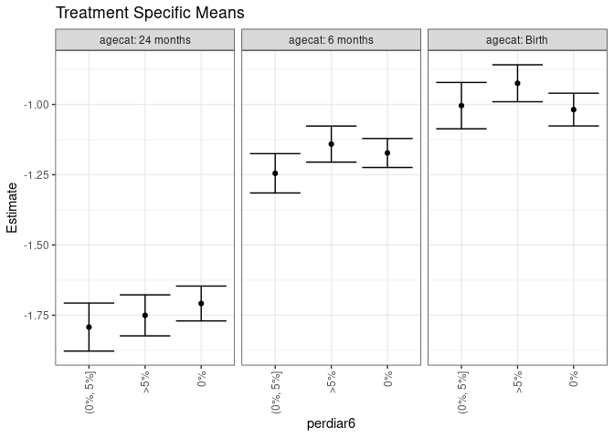

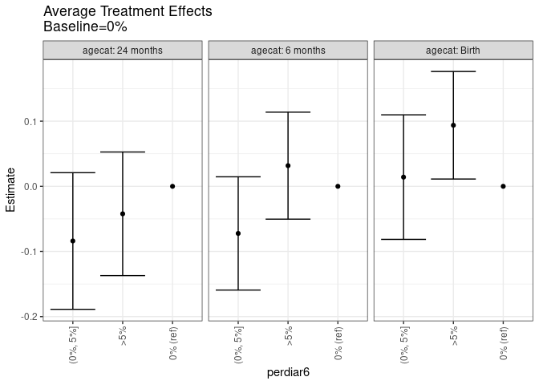

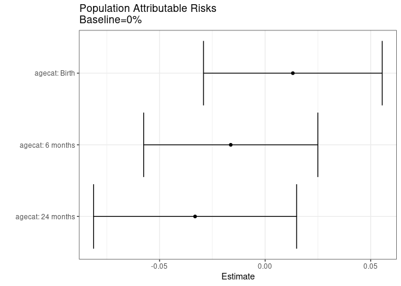

## Results Table

### Parameter: TSM

| agecat | intervention_level | baseline_level | estimate | ci_lower | ci_upper |
| --- | --- | --- | --- | --- | --- |
| Birth | 0% | NA | -1.0182447 | -1.0764590 | -0.9600305 |
| Birth | (0%, 5%] | NA | -1.0041143 | -1.0865268 | -0.9217019 |
| Birth | >5% | NA | -0.9245252 | -0.9903074 | -0.8587430 |
| 6 months | 0% | NA | -1.1726757 | -1.2242348 | -1.1211166 |
| 6 months | (0%, 5%] | NA | -1.2449886 | -1.3149501 | -1.1750271 |
| 6 months | >5% | NA | -1.1409657 | -1.2051581 | -1.0767734 |
| 24 months | 0% | NA | -1.7082974 | -1.7703210 | -1.6462739 |
| 24 months | (0%, 5%] | NA | -1.7922318 | -1.8777399 | -1.7067237 |
| 24 months | >5% | NA | -1.7505149 | -1.8234472 | -1.6775826 |

### Parameter: E(Y)

| agecat | intervention_level | baseline_level | estimate | ci_lower | ci_upper |
| --- | --- | --- | --- | --- | --- |
| Birth | NA | NA | -1.005129 | -1.044492 | -0.9657659 |
| 6 months | NA | NA | -1.188982 | -1.221254 | -1.1567087 |
| 24 months | NA | NA | -1.741494 | -1.780511 | -1.7024766 |

### Parameter: ATE

| agecat | intervention_level | baseline_level | estimate | ci_lower | ci_upper |
| --- | --- | --- | --- | --- | --- |
| Birth | 0% | 0% | 0.0000000 | 0.0000000 | 0.0000000 |
| Birth | (0%, 5%] | 0% | 0.0141304 | -0.0814548 | 0.1097156 |
| Birth | >5% | 0% | 0.0937195 | 0.0111864 | 0.1762526 |
| 6 months | 0% | 0% | 0.0000000 | 0.0000000 | 0.0000000 |
| 6 months | (0%, 5%] | 0% | -0.0723129 | -0.1592327 | 0.0146069 |
| 6 months | >5% | 0% | 0.0317100 | -0.0504143 | 0.1138343 |
| 24 months | 0% | 0% | 0.0000000 | 0.0000000 | 0.0000000 |
| 24 months | (0%, 5%] | 0% | -0.0839344 | -0.1887929 | 0.0209242 |
| 24 months | >5% | 0% | -0.0422175 | -0.1371010 | 0.0526660 |

### Parameter: PAR

| agecat | intervention_level | baseline_level | estimate | ci_lower | ci_upper |
| --- | --- | --- | --- | --- | --- |
| Birth | 0% | NA | 0.0131158 | -0.0292040 | 0.0554355 |
| 6 months | 0% | NA | -0.0163059 | -0.0575596 | 0.0249478 |
| 24 months | 0% | NA | -0.0331962 | -0.0812963 | 0.0149039 |